# Regresión local (LOESS)

Septiembre 2020

## Introducción

## Definición

La regresión local (LOESS o LOWESS) es otra aproximación para obtener modelos no lineales. Se caracteriza por ajustar modelos simples a distintas subregiones del rango del predictor empleando únicamente las observaciones cercanas, evitando así recurrir a una única función global compleja. El concepto puede recordar al descrito en regression splines y smoothing splines, de hecho, es muy similar, la diferencia es que en la regresión local las regiones son solapantes, cosa que no ocurre en los otros dos métodos.

\[Y_{i}=\mu(x_{i})+\epsilon_{i} \] Donde:

- \(\mu(x)\): Es una función desconodida
- \(\epsilon_{i}\): Es un término de error, que representa errores aleatorios en las observaciones o variabilidad de fuentes no incluidas en \(x_{i}\).

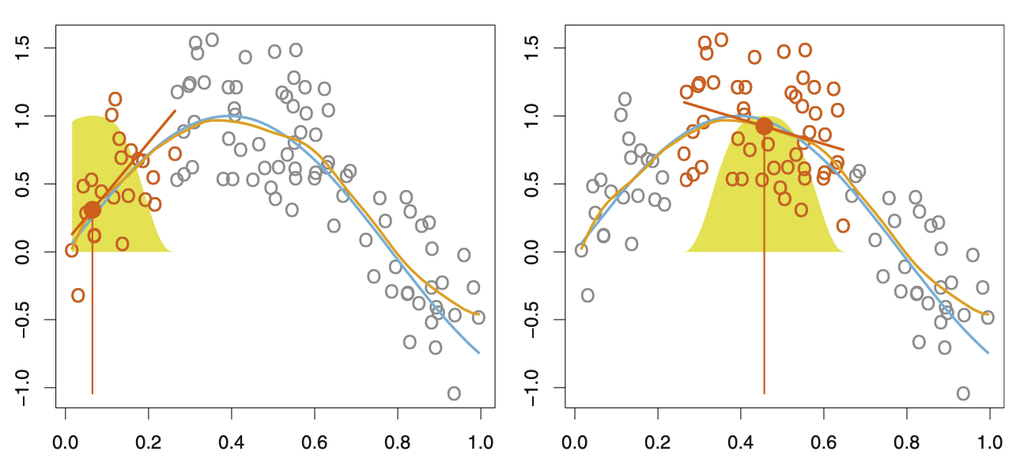

Regresión local, James et al. (2013)

## Parámetros

### - SPAN

Es el parámetro más importante y con mayor impacto en la regresión local. Su función es la de controlar la flexibilidad del ajuste.

- **Span menores:** Cuanto menor es el span, menor la fracción de observaciones vecinas empleadas en cada ajuste local y, por lo tanto, mayor flexibilidad del modelo.
- **Span mayores:** Valores altos de span hacen que en cada ajuste local se empleen muchas observaciones vecinas generando un ajuste más robusto, pero menos flexible.

### - GRADO DEL POLINOMIO

El polinomio local empleado para ajustar cada subset de datos suele ser siempre de primer o segundo grado, es decir, o bien un ajuste lineal o bien uno cuadrático. Aunque desde el punto de vista teórico se pueden emplear polinomios de mayor grado, estos tienden a producir overfit y reducen la precisión del modelo.

### - FUNCIÓN PARA DESIGNAR PESOS

\[w(x)=(1-|x|^{3})^{3} \hspace{2cm} I[|x|<1] \]

## Algoritmo

Para cada posición x0 ocupada por una observación:

1. Se identifican la fracción \(s=\frac{k}{n}\) de observaciones más cercanas al punto \(x_{0}\).
2. Se asigna un peso a cada observación vecina (dentro de las seleccionadas en el paso 1) de forma que la observación más alejada tiene peso 0 y la más cercana tiene el mayor peso. Todas las demás observaciones del set de datos tienen peso 0.
3. Ajuste weighted least squares regression.
4. El valor predicho de x0 viene dado por el ajuste obtenido en el paso 3.

## Ventajas y desventajas

### **VENTAJAS**

- Combina la simplicidad de la regresión lineal por mínimos cuadrados con la flexibilidad de la regresión no lineal.
- No necesita que especifiquemos una función para ajustar el modelo.
- Es muy flexible, lo que es ideal para el modelado de procesos complejos para los que no existen modelos teóricos.
- Es sencilla.

### **DESVENTAJAS**

- Necesita una muestra numerosa para obtener buenos modelos.
- No producen una función de regresión fácilmente representable por una fórmula matemática.
- Es sensible a los efectos de valores atípicos en los datos (al igual que en otros métodos basados en distancias cuadráticas).

## Ejemplo en R

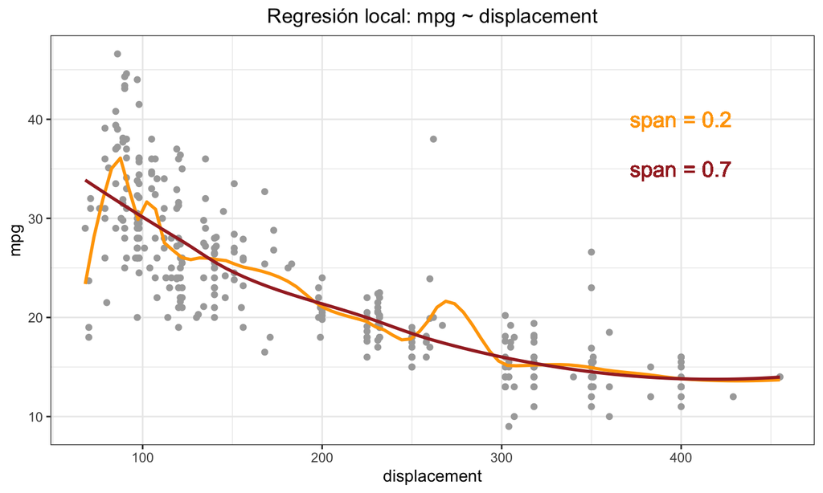

## Bibliografía

James, G., Witten, D., Hastie, T., & Tibshirani, R. (2013). *An introduction to statistical learning* (Vol. 112). Springer.